# studyFastx-toolkit

#### 2.2.2 FASTQ Quality Chart

```
$ fastq_quality_boxplot_graph.sh -h
    Solexa-Quality BoxPlot plotter
    Generates a solexa quality score box-plot graph 绘制碱基质量分布盒式图

    Usage: /usr/local/bin/fastq_quality_boxplot_graph.sh [-i INPUT.TXT] [-t TITLE] [-p] [-o OUTPUT]

      [-p]           - Generate PostScript (.PS) file. Default is PNG image.产生.PS文件，默认产生png图像
      [-i INPUT.TXT] - Input file. Should be the output of "solexa_quality_statistics" program.
      输入文件为 fastx_quality_stats的输出文件
      [-o OUTPUT]    - Output file name. default is STDOUT.
      [-t TITLE]     - Title (usually the solexa file name) - will be plotted on the graph.
      输出图像的标题
```

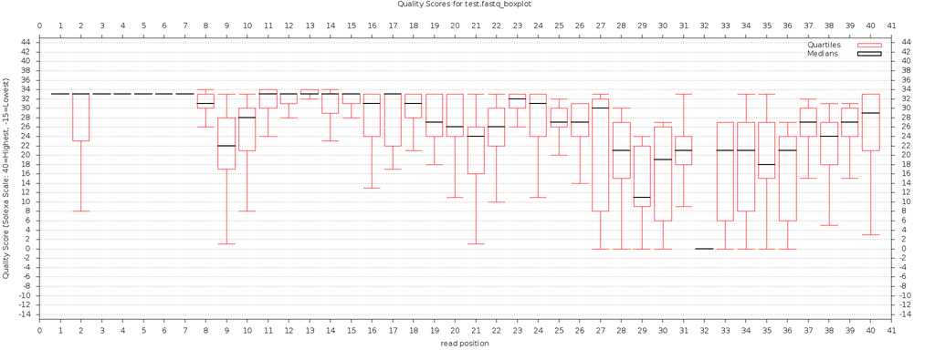

test.fastq_boxplot.png

```bash
#需要先安装gunplot
$ sudo yum install gnuplot-minimal.x86_64
$ fastq_quality_boxplot_graph.sh -i test.fastq_qualityStats -t test.fastq_boxplot  -o test.fastq_boxplot.png
```

### 2.2.3 FASTA/Q Nucleotide Distribution

```
$ fastx_nucleotide_distribution_graph.sh -h
    FASTA/Q Nucleotide Distribution Plotter

    Usage: /usr/local/bin/fastx_nucleotide_distribution_graph.sh [-i INPUT.TXT] [-t TITLE] [-p] [-o OUTPUT]

      [-p]           - Generate PostScript (.PS) file. Default is PNG image.
      [-i INPUT.TXT] - Input file. Should be the output of "fastx_quality_statistics" program.
      [-o OUTPUT]    - Output file name. default is STDOUT.
      [-t TITLE]     - Title - will be plotted on the graph.
```

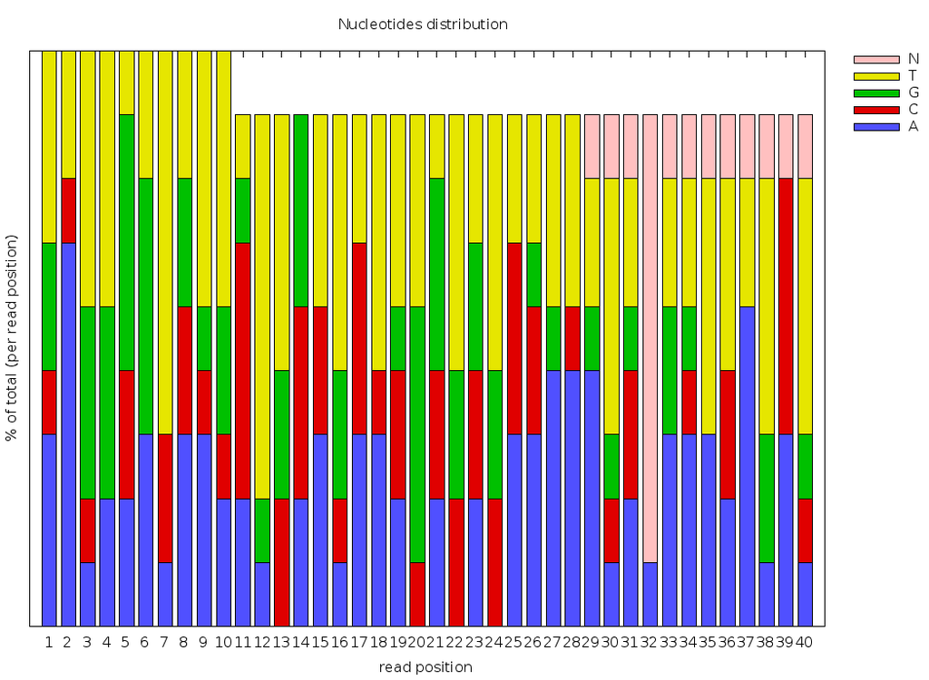

```bash
$ fastx_nucleotide_distribution_graph.sh -i test.fastq_qualityStats -o test.fastq_nucleotide_distribution_graph.png
```

上面空出来的白色的一块是因为最后测出来的结果，序列中的碱基数小于40个。

### 2.3 FASTQ/A Artifacts Filter

```
$ fastx_artifacts_filter -h
usage: fastx_artifacts_filter [-h] [-v] [-z] [-i INFILE] [-o OUTFILE]
Part of FASTX Toolkit 0.0.13 by A. Gordon (gordon@cshl.edu)

   [-h]         = This helpful help screen.
   [-i INFILE]  = FASTA/Q input file. default is STDIN.
   [-o OUTFILE] = FASTA/Q output file. default is STDOUT.
   [-z]         = Compress output with GZIP.
   [-v]         = Verbose - report number of processed reads.
                  If [-o] is specified,  report will be printed to STDOUT.
                  If [-o] is not specified (and output goes to STDOUT),
                  report will be printed to STDERR.
```

这个是人工过滤？ 但是我用的测试数据中有一条全部都是!的记录竟然没有被过滤掉。不知道这是怎么回事。

### 2. FASTQ/A Collapser

Collapsing identical sequences in a FASTQ/A file into a single sequence (while maintaining reads counts)

就是将一样的序列合并到一起，并且给出reads counts.那么测试数据就要复制一下。

```
$ fastx_collapser -h
usage: fastx_collapser [-h] [-v] [-i INFILE] [-o OUTFILE]
Part of FASTX Toolkit 0.0.13 by A. Gordon (gordon@cshl.edu)

   [-h]         = This helpful help screen.
   [-v]         = verbose: print short summary of input/output counts
   [-i INFILE]  = FASTA/Q input file. default is STDIN.
   [-o OUTFILE] = FASTA/Q output file. default is STDOUT.
```

显示的结果为：

```
>1-1
TTTTCTTGTTCTTGACTCTTCTGCATAAGTANTTAAATCC
>2-1
TATGCATCACATTCTTCTGGTTCTACTTTGCNATTTATCT
```

### 2. FASTQ/A uncollapser 同上面的相反

```
$ fastx_uncollapser -h
usage: fasta_uncollapser [-c N] [-h] [-v] [-i INFILE] [-o OUTFILE]
Part of FASTX Toolkit 0.0.13 by A. Gordon (gordon@cshl.edu)

   [-h]         = This helpful help screen.
   [-v]         = verbose: print short summary of input/output counts
   [-c N]       = Assume input is a tabular file (not FASTA file),
                  And the collapsed identifier (e.g. '1-1000') is on column N.
   [-i INFILE]  = FASTA/Tabular input file. default is STDIN.
   [-o OUTFILE] = FASTA/Tabular output file. default is STDOUT.
```

### 2. FASTQ/A Trimmer

Shortening reads in a FASTQ or FASTQ files (removing barcodes or noise).

```
$ fastx_trimmer -h
    usage: fastx_trimmer [-h] [-f N] [-l N] [-z] [-v] [-i INFILE] [-o OUTFILE] 从3'开始到5'哪些部分保留

    version 0.0.6
       [-h]         = This helpful help screen.
       [-f N]       = First base to keep. Default is 1 (=first base).从第几个碱基开始保留，默认第一个
       [-l N]       = Last base to keep. Default is entire read.后面从第几个碱基开始保留，默认全部碱基都保留.
       [-t N]       = Trim N nucleotides from the end of the read.
                  '-t'  can not be used with '-l' and '-f'.
     [-m MINLEN]  = With [-t], discard reads shorter than MINLEN. 小于MINLEN长度的read去掉
       [-z]         = Compress output with GZIP.
       [-i INFILE]  = FASTA/Q input file. default is STDIN.
       [-o OUTFILE] = FASTA/Q output file. default is STDOUT.
```

**-f** 是保留从N个开始的碱基 **-l** 是保留到正数(从左到右)的第N个碱基 **-t** 是除去右端的N个碱基

### 2. FASTQ/A Renamer

Renames the sequence identifiers in FASTQ/A file.

```
$ fastx_renamer -h
    usage: fastx_renamer [-n TYPE] [-h] [-z] [-v] [-i INFILE] [-o OUTFILE]
    Part of FASTX Toolkit 0.0.10 by A. Gordon (gordon@cshl.edu)

       [-n TYPE]    = rename type:
              SEQ - use the nucleotides sequence as the name.
              COUNT - use simply counter as the name.
       [-h]         = This helpful help screen.
       [-z]         = Compress output with GZIP.
       [-i INFILE]  = FASTA/Q input file. default is STDIN.
       [-o OUTFILE] = FASTA/Q output file. default is STDOUT.
```

```bash
$ fastx_renamer -Q 33 -n SEQ -v -i test.fastq -o test.fastq_rename.fastq
```

```
Renamed: 9 reads.
```

就是在fastq文件的第一行用序列作为id

### 2. FASTQ/A Clipper

Removing sequencing adapters / linkers

```
$ fastx_clipper -h
    usage: fastx_clipper [-h] [-a ADAPTER] [-D] [-l N] [-n] [-d N] [-c] [-C] [-o] [-v] [-z] [-i INFILE] [-o OUTFILE]

    version 0.0.7
       [-h]         = This helpful help screen.
       [-a ADAPTER] = ADAPTER string. default is CCTTAAGG (dummy adapter).接头序列（默认为CCTTAAGG）
       [-l N]       = discard sequences shorter than N nucleotides. default is 5.忽略那些碱基数目少于N的reads，默认为5
       [-d N]       = Keep the adapter and N bases after it.保留接头序列后的N个碱基默认  -d 0
              (using '-d 0' is the same as not using '-d' at all. which is the default).
       [-c]         = Discard non-clipped sequences (i.e. - keep only sequences which contained the adapter).
                    放弃那些没有接头的序列.
       [-C]         = Discard clipped sequences (i.e. - keep only sequences which did not contained the adapter).
                    只保留没有接头的序列.
       [-k]         = Report Adapter-Only sequences.
                    报告只有接头的序列.
       [-n]         = keep sequences with unknown (N) nucleotides. default is to discard such sequences.
                    保留有N多序列，默认不保留
       [-v]         = Verbose - report number of sequences.详细-报告序列编号
              If [-o] is specified,  report will be printed to STDOUT.
              If [-o] is not specified (and output goes to STDOUT),
              report will be printed to STDERR.
       [-z]         = Compress output with GZIP.压缩输出.
       [-D]     = DEBUG output.输出调试结果.
       [-M N]       = require minimum adapter alignment length of N.要求最小能匹配到接头的长度N，如果和接头匹配的长度小于N不修剪
                  If less than N nucleotides aligned with the adapter - don't clip it.
       [-i INFILE]  = FASTA/Q input file. default is STDIN.
       [-o OUTFILE] = FASTA/Q output file. default is STDOUT.
```

```bash
$ fastx_clipper -Q 33 -a TTAAATCC -l -c -v -i test.fastq -o test.fastq_clipperTest_onlyFirstRecordHaveAdapter.fastq
```

```
Clipping Adapter: TTAAATCC
Min. Length: 0
Input: 9 reads.
Output: 2 reads.
discarded 0 too-short reads.
discarded 0 adapter-only reads.
discarded 7 N reads.
```

感觉这里有些参数貌似不对输出的结果起作用：-c和-C 貌似是和-v 参数在一起起作用的。

**-D** 这个参数挺好用的可以看看去接头的情况，只可意会不能言传，大家自己去体会吧

### 2. FASTQ/A Reverse-Complement

Producing the Reverse-complement of each sequence in a FASTQ/FASTA file.

```
$ fastx_reverse_complement -h
usage: fastx_reverse_complement [-h] [-r] [-z] [-v] [-i INFILE] [-o OUTFILE]
Part of FASTX Toolkit 0.0.13 by A. Gordon (gordon@cshl.edu)

   [-h]         = This helpful help screen.
   [-z]         = Compress output with GZIP.
   [-i INFILE]  = FASTA/Q input file. default is STDIN.
   [-o OUTFILE] = FASTA/Q output file. default is STDOUT.
```

顾名思义

### 2. FASTA Clipping Histogram

> requires two perl modules: PerlIO::gzip and GD::Graph::bars.

### 2. FASTQ/A Barcode splitter

Splitting a FASTQ/FASTA files containning multiple samples

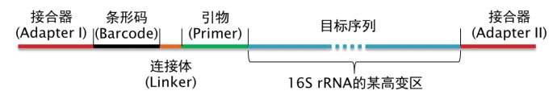

where is barcode

```
$ fastx_barcode_splitter.pl -h
Barcode Splitter, by Assaf Gordon (gordon@cshl.edu), 11sep2008

This program reads FASTA/FASTQ file and splits it into several smaller files,
Based on barcode matching.
基于barcode序列将fastq/a文件进行拆分！
FASTA/FASTQ data is read from STDIN (format is auto-detected.)
Output files will be writen to disk.
Summary will be printed to STDOUT.

usage: /home/lang/fastx-tool/bin/fastx_barcode_splitter.pl --bcfile FILE --prefix PREFIX [--suffix SUFFIX] [--bol|--eol]
         [--mismatches N] [--exact] [--partial N] [--help] [--quiet] [--debug]

Arguments:

--bcfile FILE   - Barcodes file name. (see explanation below.) bcfile文件，具体的文件格式见下文
--prefix PREFIX - File prefix. will be added to the output files. Can be used
          to specify output directories.
--suffix SUFFIX - File suffix (optional). Can be used to specify file
          extensions.
--bol       - Try to match barcodes at the BEGINNING of sequences.
          (What biologists would call the 5' end, and programmers
          would call index 0.)
--eol       - Try to match barcodes at the END of sequences.
          (What biologists would call the 3' end, and programmers
          would call the end of the string.)
          NOTE: one of --bol, --eol must be specified, but not both.
--mismatches N  - Max. number of mismatches allowed. default is 1.
--exact     - Same as '--mismatches 0'. If both --exact and --mismatches
          are specified, '--exact' takes precedence.
--partial N - Allow partial overlap of barcodes. (see explanation below.)
          (Default is not partial matching)
--quiet     - Don't print counts and summary at the end of the run.
          (Default is to print.)
--debug     - Print lots of useless debug information to STDERR.
--help      - This helpful help screen.

Example (Assuming 's_2_100.txt' is a FASTQ file, 'mybarcodes.txt' is
the barcodes file):

```

[output cut: 62 more lines]

```
Input sequence is ATTTACTATGTAAAGATAGAAGGAATAAGGTGAAG
(Same as above, but note the missing 'G' at the beginning.)

Matching (without partial overlapping) against BC1 yields 4 mismatches:
   ATTTACTATGTAAAGATAGAAGGAATAAGGTGAAG
   GATCT (4 mismatches)

Partial overlapping would also try the following match:
   -ATTTACTATGTAAAGATAGAAGGAATAAGGTGAAG
   GATCT (1 mismatch)

Note: scoring counts a missing base as a mismatch, so the final
mismatch count is 2 (1 'real' mismatch, 1 'missing base' mismatch).
If running with '--mismatches 2' (meaning allowing upto 2 mismatches) - this
seqeunce will be classified as BC1.
```

### 2. FASTA Formatter

changes the width of sequences line in a FASTA file

```
$ fasta_formatter -h
usage: fasta_formatter [-h] [-i INFILE] [-o OUTFILE] [-w N] [-t] [-e]
Part of FASTX Toolkit 0.0.13 by gordon@cshl.edu

   [-h]         = This helpful help screen.
   [-i INFILE]  = FASTA/Q input file. default is STDIN.
   [-o OUTFILE] = FASTA/Q output file. default is STDOUT.
   [-w N]       = max. sequence line width for output FASTA file.
                  When ZERO (the default), sequence lines will NOT be wrapped -
                  all nucleotides of each sequences will appear on a single
                  line (good for scripting).
   [-t]         = Output tabulated format (instead of FASTA format).
                  Sequence-Identifiers will be on first column,
                  Nucleotides will appear on second column (as single line).
   [-e]         = Output empty sequences (default is to discard them).
                  Empty sequences are ones who have only a sequence identifier,
                  but not actual nucleotides.

Input Example:
   >MY-ID
   AAAAAGGGGG
   CCCCCTTTTT
   AGCTN

Output example with unlimited line width [-w 0]:
   >MY-ID
   AAAAAGGGGGCCCCCTTTTTAGCTN

Output example with max. line width=7 [-w 7]:
   >MY-ID
   AAAAAGG
   GGGTTTT
   TCCCCCA
   GCTN

Output example with tabular output [-t]:
   MY-ID    AAAAAGGGGGCCCCCTTTTAGCTN

example of empty sequence:
(will be discarded unless [-e] is used)
  >REGULAR-SEQUENCE-1
  AAAGGGTTTCCC
  >EMPTY-SEQUENCE
  >REGULAR-SEQUENCE-2
  AAGTAGTAGTAGTAGT
  GTATTTTATAT
```

帮助文件中说的很清楚了！

### FASTA Nucleotide Changer

Convets FASTA sequences from/to RNA/DNA

```
$ fasta_nucleotide_changer -h
usage: fasta_nucleotide_changer [-h] [-z] [-v] [-i INFILE] [-o OUTFILE] [-r] [-d]
Part of FASTX Toolkit 0.0.13 by A. Gordon (gordon@cshl.edu)

   [-h]         = This helpful help screen.
   [-z]         = Compress output with GZIP.
   [-v]         = Verbose mode. Prints a short summary.
                  with [-o], summary is printed to STDOUT.
                  Otherwise, summary is printed to STDERR.
   [-i INFILE]  = FASTA/Q input file. default is STDIN.
   [-o OUTFILE] = FASTA/Q output file. default is STDOUT.
   [-r]         = DNA-to-RNA mode - change T's into U's.
   [-d]         = RNA-to-DNA mode - change U's into T's.
```

就是把序列中的U和T转转！

### 2. FASTQ Quality Filter

Filters sequences based on quality

```
$ fastq_quality_filter -h
    usage: fastq_quality_filter [-h] [-v] [-q N] [-p N] [-z] [-i INFILE] [-o OUTFILE]

    version 0.0.6
       [-h]         = This helpful help screen.
       [-q N]       = Minimum quality score to keep.最小的需要留下的质量值
       [-p N]       = Minimum percent of bases that must have [-q] quality.每个reads中最少有百分之多少的碱基需要有-q的质量值
       [-z]         = Compress output with GZIP.压缩输出
       [-i INFILE]  = FASTA/Q input file. default is STDIN.
       [-o OUTFILE] = FASTA/Q output file. default is STDOUT.
       [-v]         = Verbose - report number of sequences.详细-报告序列编号，如果使用了-o则报告会直接在STDOUT，如果没有则输入到STDERR
              If [-o] is specified,  report will be printed to STDOUT.
              If [-o] is not specified (and output goes to STDOUT),
              report will be printed to STDERR.
```

测试数据的数量为9×4，其中有两条是有最差的！的

```bash
$ fastq_quality_filter -i test.fastq -Q 33 -v -q 20 -p 50 -o test.fastq_filterq20p50.fastq
```

```
Quality cut-off: 20
Minimum percentage: 50
Input: 9 reads.
Output: 7 reads.
discarded 2 (22%) low-quality reads.
```

### 2. FASTQ Quality Trimmer

Trims (cuts) sequences based on quality

```
$ fastq_quality_trimmer -h
usage: fastq_quality_trimmer [-h] [-v] [-t N] [-l N] [-z] [-i INFILE] [-o OUTFILE]
Part of FASTX Toolkit 0.0.13 by A. Gordon (gordon@cshl.edu)

   [-h]         = This helpful help screen.
   [-t N]       = Quality threshold - nucleotides with lower
                  quality will be trimmed (from the end of the sequence).
   [-l N]       = Minimum length - sequences shorter than this (after trimming)
                  will be discarded. Default = 0 = no minimum length.
   [-z]         = Compress output with GZIP.
   [-i INFILE]  = FASTQ input file. default is STDIN.
   [-o OUTFILE] = FASTQ output file. default is STDOUT.
   [-v]         = Verbose - report number of sequences.
                  If [-o] is specified,  report will be printed to STDOUT.
                  If [-o] is not specified (and output goes to STDOUT),
                  report will be printed to STDERR.
```

通过测试，对于 **-t** 这个选项它的执行结果是：

fastq中的序列中的碱基的测序质量低于某一个阈值时，将序列从这个碱基到最后的哪一部分去掉。

比如ATGCTGAG 的质量分数为 33 22 11 33 21 30 25 23 你选择 30 的阈值的话，它会从右往左检索第一个小于30的碱基，然后把这个碱基之后的序列全部删去。

### 2. fastq_quality_converter

个人觉得这个价值不大！

```
$ fastq_quality_converter -h
usage: fastq_quality_converter [-h] [-a] [-n] [-z] [-i INFILE] [-f OUTFILE]
Part of FASTX Toolkit 0.0.13 by A. Gordon (gordon@cshl.edu)

   [-h]         = This helpful help screen.
   [-a]         = Output ASCII quality scores (default).
   [-n]         = Output numeric quality scores.
   [-z]         = Compress output with GZIP.
   [-i INFILE]  = FASTA/Q input file. default is STDIN.
   [-o OUTFILE] = FASTA output file. default is STDOUT.
```

### 2. FASTQ Masker

Masks nucleotides with ‘N’ (or other character) based on quality

```
$ fastq_masker -h
usage: fastq_masker [-h] [-v] [-q N] [-r C] [-z] [-i INFILE] [-o OUTFILE]
Part of FASTX Toolkit 0.0.13 by A. Gordon (gordon@cshl.edu)

   [-h]         = This helpful help screen.
   [-q N]       = Quality threshold - nucleotides with lower quality will be masked
                  Default is 10.
                  质量门限值，质量值低于这个门限值的将被mask掉（就是变成N），默认值为10
   [-r C]       = Replace low-quality nucleotides with character C. Default is 'N'
   [-z]         = Compress output with GZIP.
   [-i INFILE]  = FASTQ input file. default is STDIN.
   [-o OUTFILE] = FASTQ output file. default is STDOUT.
   [-v]         = Verbose - report number of sequences.
                  If [-o] is specified,  report will be printed to STDOUT.
                  If [-o] is not specified (and output goes to STDOUT),
                  report will be printed to STDERR.
```

masker的意思就是，通过设定**-q**参数 将低于某一质量分数的碱基用N表示。

> 部分中文翻译摘自：http://blog.sciencenet.cn/blog-1509670-848270.html

Go back